# Home Advantage Within the National Basketball Association (Season 2015-2018)

Roos van Velthoven

May 2021

Please ensure you have installed:

- [R](https://cran.r-project.org/mirrors.html)
- [Rstudio](https://www.rstudio.com/products/rstudio/download/)
- [Rtools40](https://clanfear.github.io/CSSS508/docs/compiling.html) for Windows or [Xcode Command Line Tools](https://clanfear.github.io/CSSS508/docs/compiling.html) for Mac
- Git (for [Windows](https://git-scm.com/download/win) or [Mac](https://git-scm.com/download/mac))
- [MikTex](https://miktex.org/download)

For my GitHub repository please click [here](https://github.com/RoosvanVelthoven/roos_van_velthoven_psy6422_200256845):

- Please clone my git repository
- Please open index.Rmd
- Please enter renv::restore()
- Please enter y

*Please utilize the aforementioned steps to restore my project library, locally, on your machine.*

# Research Question

When sports are played with a balanced home and away schedule, the home team wins over 50% of their matches (Courneya & Carron, 1992).

For the PSY6422 assignment I am visualising home advantage within the National Basketball Association (NBA) from the 2015 season till the 2018 season.

The visualisation will aim to address the following question:

**Do home teams, on average, score more points than away teams?**

**Season span: season 2015 (2015-2016), season 2016 (2016-2017), season 2017 (2017-2018) and season 2018 (2018-2019)*

**Data from subsequent seasons are excluded, the COVID-19 pandemic may have influenced home advantage (e.g., through crowd restrictions)*

# Data Origin

The data set **games.csv** was obtained through [Kaggle](https://www.kaggle.com/nathanlauga/nba-games), the data set was published by Nathan Lauga.

The data was collected from the [NBA statistics website](https://www.nba.com/stats/), please click [here](https://github.com/Nathanlauga/nba-predictor) for more information (and please click [here](https://github.com/swar/nba_api/blob/master/docs/table_of_contents.md) for more information on Application Programming Interface (API) endpoints).

The data set contains NBA games from 05/10/2003 till present (the data is updated periodically; the expected update frequency is quarterly).

To particularise, the data set contains information on game date, game ID, game status (final means that the game was completed), home team ID, visitor team ID, **season**, team ID of the home team, **points scored by the home team**, field goal percentage of the home team, free throw percentage of the home team, three-point percentage of the home team, assists of the home team, rebounds of the home team, team ID of the away team, **points scored by the away team**, field goal percentage of the away team, free throw percentage of the away team, three-point percentage of the away team, assists of the away team, rebounds of the away team and **wins of the home team**.

```r
# Code to read in games.csv
nba_raw <- read.csv(here("data", "raw", "games.csv"))
# nba_raw = raw data
```

Of interest, to the current assignment, are the variables in **bold**.

*First three rows of the raw data:*

```
##   GAME_DATE_EST  GAME_ID GAME_STATUS_TEXT HOME_TEAM_ID VISITOR_TEAM_ID SEASON
## 1    21/03/2021 22000645            Final   1610612748      1610612754   2020
## 2    21/03/2021 22000016            Final   1610612745      1610612760   2020
## 3    21/03/2021 22000646            Final   1610612743      1610612740   2020
##   TEAM_ID_home PTS_home FG_PCT_home FT_PCT_home FG3_PCT_home AST_home REB_home
## 1   1610612748      106       0.402       0.826        0.243       27       51
## 2   1610612745      112       0.494       0.741        0.368       22       38
## 3   1610612743      108       0.500       0.800        0.353       30       37
##   TEAM_ID_away PTS_away FG_PCT_away FT_PCT_away FG3_PCT_away AST_away REB_away
## 1   1610612754      109       0.388       0.900        0.333       27       50
## 2   1610612760      114       0.462       0.680        0.333       22       52
## 3   1610612740      113       0.482       0.767        0.286       26       45
##   HOME_TEAM_WINS
## 1              0
## 2              0
## 3              0
```

# Data Preparation

```r
# Code to specify which variables to keep
nba_variables <-  nba_raw %>%
  select(SEASON, PTS_home, PTS_away, HOME_TEAM_WINS)
# nba_variables = data of solely the variables of interest

# Code to rename columns for easy labelling
nba_relabelled <- nba_variables %>%
  rename(points_home = "PTS_home", points_away = "PTS_away", season = "SEASON",
         home_win = "HOME_TEAM_WINS")

# Code to recode home_win values 1 to won and 0 to lost
nba_relabelled[nba_relabelled == "1"] <- "Won"
nba_relabelled[nba_relabelled == "0"] <- "Lost"

# nba_relabelled = data with relabelled variables and recoded home_win values (1 = won and 0 = lost)

# Code to save the relabelled data frame
write.csv(nba_relabelled, file = here("data", "processed", "nba_relabelled.csv"))
```

```r
# Code to specify which seasons to keep
nba_2018_2015 <- nba_relabelled[ !(nba_relabelled$season %in% c(2020:2019, 2014:2003)), ]
# nba_2018_2015 = data of the 2015-2018 seasons

# Code to save nba_2018_2015 as a csv file (I need this later for my min and max values)
write.csv(nba_2018_2015, file = here("data", "processed", "nba_2018_2015.csv"))
```

```r
# Code to keep season 2018
nba18 <- nba_2018_2015[ !(nba_2018_2015$season %in% c(2020:2019, 2017:2003)), ]
# nba18 = data of solely the 2018 season

# Code to rename columns for easy labelling when data frames are combined
nba18 <- nba18 %>% rename(points_home_18 = "points_home", points_away_18 = "points_away", season_18 = "season", home_win_18 = "home_win")
```

The above process was repeated to create nba17, nba16 and nba15 data frames.

```r
# Code to add ID numbers, I need specific keys to merge my data frames
nba18 <- nba18 %>% mutate(id = row_number())
nba17 <- nba17 %>% mutate(id = row_number())
nba16 <- nba16 %>% mutate(id = row_number())
nba15 <- nba15 %>% mutate(id = row_number())

# Each data frame has a different number of games, to merge the data frames without
# losing data, I need to do a full(outer) join.

# Code to merge nba18 and nba17, I can only merge two data frames with this code
full18_17 <- merge(nba18, nba17, by = "id", all = TRUE)

# Code to merge nba16 and nba15
full16_15 <- merge(nba16, nba15, by = "id", all = TRUE)

# Code to merge full18_17 and full16_15
full18_15 <- merge(full18_17, full16_15, by = "id", all = TRUE)

# Time to rename my data frame to reduce confusion
nba_final_df <- full18_15

# Code to remove the season columns
nba_final_df <- select(nba_final_df,-season_18, -season_17, -season_16, -season_15)

# Code to save my final data set as a csv file
write.csv(nba_final_df, file = here("data", "processed", "nba_final_df.csv"))
# nba_final_df = data set that I will use for my plots
```

*First three rows of the processed data:*

```
##   id points_home_18 points_away_18 home_win_18 points_home_17 points_away_17
## 1  1            110            114        Lost             85            108
## 2  2            105            106        Lost            102            110
## 3  3             92            105        Lost            122            103
##   home_win_17 points_home_16 points_away_16 home_win_16 points_home_15
## 1        Lost            129            120         Won             89
## 2        Lost            137            116         Won            115
## 3         Won            113            118        Lost             97
##   points_away_15 home_win_15
## 1             93        Lost
## 2            101         Won
## 3            112        Lost
```

# Visualisation of the 2015, 2016, 2017 and 2018 Season

```r
# Step one: I need two lists of variables to iterate over
points_home <- c("points_home_15","points_home_16","points_home_17","points_home_18")
points_away <- c("points_away_15","points_away_16","points_away_17","points_away_18")

# Step two: I need a list of variables for my colour and shape
home_win <- c("home_win_15","home_win_16","home_win_17","home_win_18")

# Step three: I need a list of titles
season <- c("Home Advantage Within the NBA: Season 2015", "Home Advantage Within the NBA: Season 2016", "Home Advantage Within the NBA: Season 2017", "Home Advantage Within the NBA: Season 2018")

# Step four: I need plot parameters
xlab  <-  'Points scored by the home team'
ylab  <-  'Points scored by the away team'
pointsize  <-  2
alpha <- .5
h <- "The home team:"
```

```r
# Step five: I need xlim and ylim values
min(nba_2018_2015$points_home) ## [1] 64
max(nba_2018_2015$points_home) ## [1] 161
# I will use 60 - 165 for my xlim
min(nba_2018_2015$points_away) ## [1] 65
max(nba_2018_2015$points_away) ## [1] 168
# I will use 60 - 170 for my ylim
```

```r
# Step six: I need a loop to look at points_away and points_home across four seasons

# Code to start saving my GIF
saveGIF({
# Code to start my loop
  for (i in 1:4){

  mx <- mean(nba_final_df[,points_home[i]], na.rm = TRUE)
# This will be used for my subtitle, it determines the mean value of points scored by the home team in a certain season and then assigns it to an object.
# na.rm = TRUE removes missing values of the data (so they do not affect mean scores)
  my <- mean(nba_final_df[,points_away[i]], na.rm = TRUE)
# This will be used for my subtitle, it determines the mean value of points scored by the away team in a certain season and then assigns it to an object.

    nba_plots <-
      ggplot(data = nba_final_df,
           mapping = aes_string (x = points_home[i],
# First lists of variables to iterate over
                                 y = points_away[i],
# Second lists of variables to iterate over
                                 colour = home_win[i],
# Code to have different colours for games won or lost by the home team
                                 shape = home_win[i]))
# Code to have different shapes for games won or lost by the home team

# Step seven: time to add plot parameters
    p <- nba_plots +
              geom_point (size = pointsize, alpha = alpha) +
                    labs(x = xlab, y = ylab, title = season[i],
                         subtitle = sprintf("Mean points scored by the home team = %.1f,
mean points scored by the away team = %.1f", mx,my)) +
                    xlim(60, 165) +
                    ylim(60, 170) +
                    scale_colour_discrete(h, na.translate = FALSE) +
# Code necessary to have different colours for games won or lost by the home team
                    scale_shape_discrete(h, na.translate=FALSE) +
# Code necessary to have different shapes for games won or lost by the home team
                    theme(text = element_text(size = 12))
# Code to set text to size 12

        ggsave(filename = paste("figs/nba",toString(i),".png",sep=""))
# Code to save the plots (nba1.png, nba2.png, nba3.png and nba4.png)

  print(p)}

},interval = 8,                            # 8 seconds interval
  movie.name = "visualisation.gif",
  ani.height = 500,
  ani.width = 700,
  ani.res = 100)                           # Resolution
# My GIF was saved as visualisation.gif
```

**Do home teams, on average, score more points than away teams?**

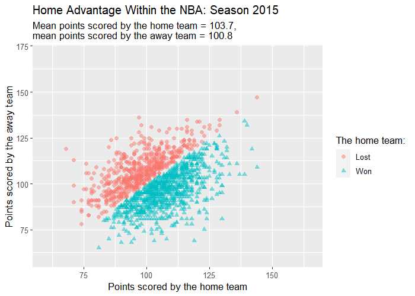

The home team scored, on average, more than the away team (please see the subtitle).

**Please allow eight seconds for the graph to update*

# Summary

In sum, the visualisation showed that, although the home team, on average, scored more points than the away team, the difference is not large; the visualisation suggests that the number of points scored by home teams and away teams are similar. When exploring home advantage data, it may, thus, be useful to visualise variables.

If I had more time, I would create an interactive web application, through the shiny package. I would like to give users the opportunity to decide which season to look at. Moreover, I would have visualised additional variables (e.g., fouls, three throws or home win ratios) to explore how they impact home advantage. Lastly, I would have compared visualisations of a pre-Covid-19 season with visualisations of a Covid-19 season. To explore if the Covid-19 pandemic influenced home advantage.

# Appendix

- Non-animated visualisation of the 2015 season

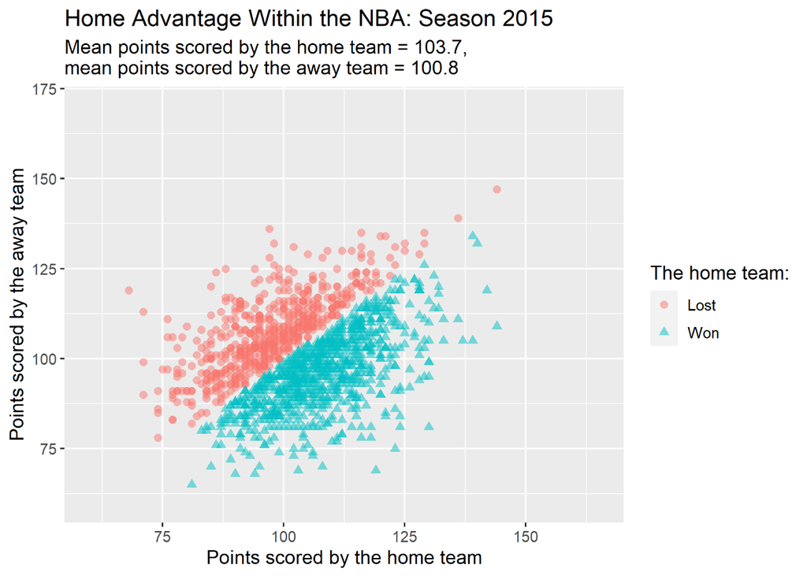

- Non-animated visualisation of the 2016 season

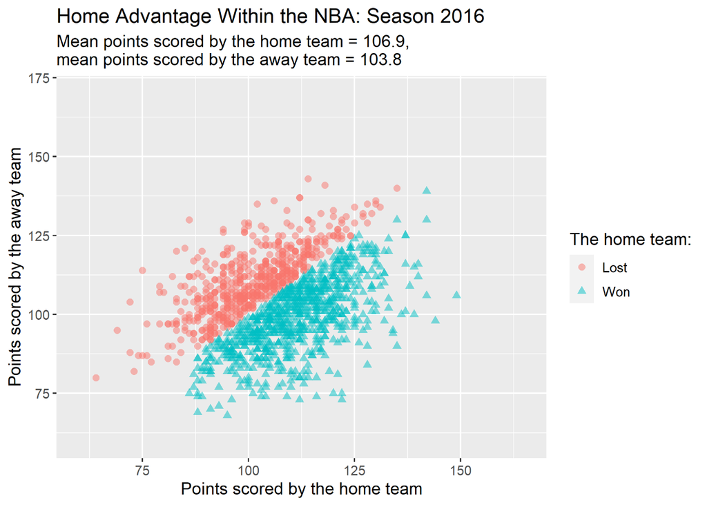

- Non-animated visualisation of the 2017 season

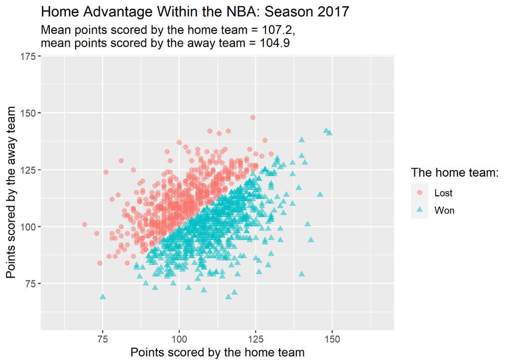

- Non-animated visualisation of the 2018 season

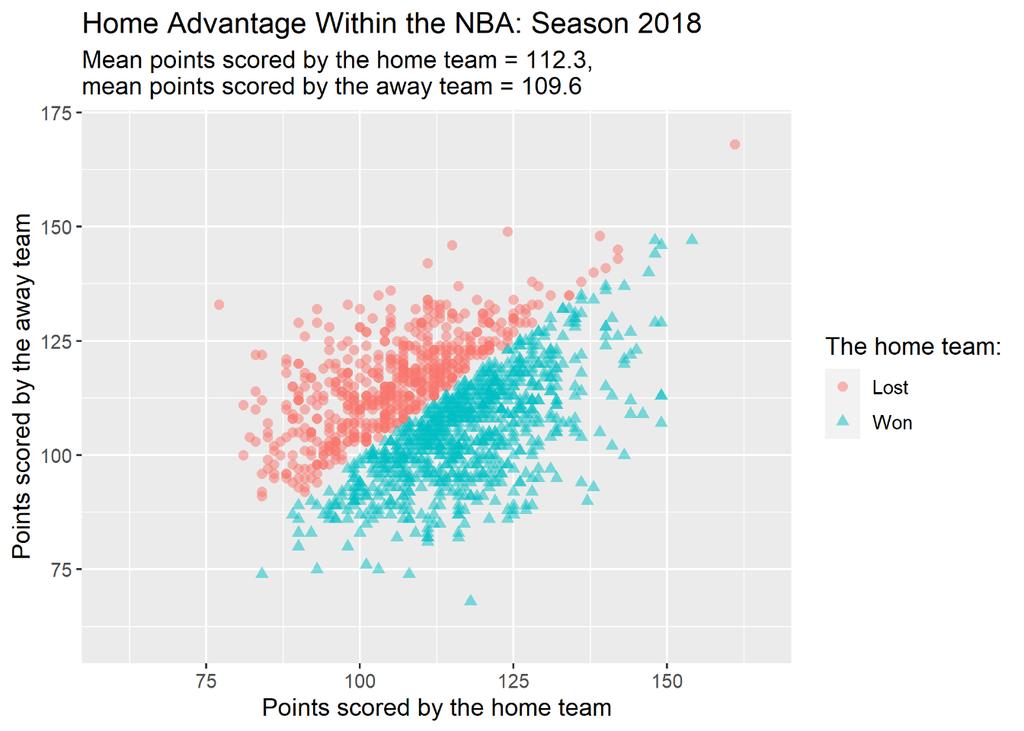